# Data preparation for Shiny Dashboard

Jennifer Crockett (copyright 2024)

2024-02-23

# Background

## Purpose

Acute Myeliod Leukemia (AML) is a type of blood cancer. There are many known genetic mutations associated with AML, which define genetic subtypes of this disease. Increasing our understanding these genetic subtypes can help us to develop better treatments for AML. Researchers often want to know if a gene is active or inactive in a genetic subtype of AML. For example, a gene that is turned on highly in a particular genetic subtype could be a new drug-target to treat that AML subtype.

Here I will develop a Shiny App that allows researchers to query a gene and see if it is active or inactive in the various genetic subtypes of AML defined by common mutations.

# Data acquisition

In this report, I will prepare the data for the Shiny App. The source of the data is the Oregon Health & Science University (OHSU) Beat AML dataset, a very large collection of AML patient data including RNA-seq gene expression data (quantitative data about how “on” or “off” a gene is) and genetic mutation data (to define genetic subtypes of AML). For more information, see the Beat AML dataset publication by Bottomly *et al.* (2022).

## Download

The Beat AML data was downloaded from the following public resource: https://biodev.github.io/BeatAML2/

## Load

RNA-seq gene expression data:

```r
rna <- read_delim(here("raw_data", "beataml_waves1to4_norm_exp_dbgap.txt"), delim = "\t", show_col_types = F)

# dimensions of dataset
dim(rna)
```

```
## [1] 22843   711
```

```r
# preview the data
rna[1:5,1:8]
```

| stable_id | display_label | description | biotype | BA2392R | BA2611R | BA2506R | BA2430R |
| --- | --- | --- | --- | --- | --- | --- | --- |
| ENSG00000000003 | TSPAN6 | tetraspanin 6 [Source:HGNC Symbol;Acc:11858] | protein_coding | 1.523670 | 1.856566 | 1.701307 | 1.870627 |
| ENSG00000000419 | DPM1 | dolichyl-phosphate mannosyltransferase polypeptide 1, catalytic subunit [Source:HGNC Symbol;Acc:3005] | protein_coding | 7.107711 | 6.865282 | 6.889932 | 6.969120 |
| ENSG00000000457 | SCYL3 | SCY1-like 3 (S. cerevisiae) [Source:HGNC Symbol;Acc:19285] | protein_coding | 3.362605 | 3.320940 | 3.407834 | 3.265446 |
| ENSG00000000460 | C1orf112 | chromosome 1 open reading frame 112 [Source:HGNC Symbol;Acc:25565] | protein_coding | 3.881649 | 4.045935 | 3.904311 | 4.057645 |
| ENSG00000000938 | FGR | feline Gardner-Rasheed sarcoma viral oncogene homolog [Source:HGNC Symbol;Acc:3697] | protein_coding | 4.571577 | 4.433159 | 4.576913 | 4.468458 |

Genetic mutation data:

```r
mut <- read_delim(here("raw_data", "beataml_wes_wv1to4_mutations_dbgap.txt") , delim = "\t", show_col_types = F)

# dimensions of dataset
dim(mut)
```

```
## [1] 11721    32
```

```r
# preview the data
mut[1:5,1:20]
```

| dbgap_sample_id | capture_type | seqnames | pos_start | pos_end | ref | alt | genotyper | tumor_only | total_reads | allele_reads | normal_total_reads | normal_allele_reads | t_vaf | n_vaf | variant_classification | hgvsp_short | gene | symbol | biotype |
| --- | --- | --- | --- | --- | --- | --- | --- | --- | --- | --- | --- | --- | --- | --- | --- | --- | --- | --- | --- |
| BA2336D | NexteraV1.2 | 4 | 106156042 | 106156043 | TC | T | varscan | 1 | 151 | 68 | 0 | 0 | 0.4503311 | 0 | frameshift_variant | p.Q317Rfs*30 | ENSG00000168769 | TET2 | protein_coding |
| BA2336D | NexteraV1.2 | 4 | 106190829 | 106190830 | AG | A | varscan | 1 | 74 | 28 | 0 | 0 | 0.3783784 | 0 | frameshift_variant | p.V1371Sfs*77 | ENSG00000168769 | TET2 | protein_coding |
| BA2336D | NexteraV1.2 | 5 | 170837543 | 170837543 | C | CTCTG | varscan | 1 | 59 | 17 | 0 | 0 | 0.2881356 | 0 | frameshift_variant | p.W288Cfs*12 | ENSG00000181163 | NPM1 | protein_coding |
| BA2643D | NexteraV1.2 | 11 | 32456651 | 32456652 | GC | G | varscan | 1 | 51 | 18 | 0 | 0 | 0.3529412 | 0 | frameshift_variant | p.A82Pfs*15 | ENSG00000184937 | WT1 | protein_coding |
| BA2643D | NexteraV1.2 | 2 | 25457242 | 25457242 | C | T | mutect | 1 | 28 | 11 | 0 | 0 | 0.3928571 | 0 | missense_variant | p.R882H | ENSG00000119772 | DNMT3A | protein_coding |

Clinical metadata:

```r
meta <- read_xlsx(here("raw_data", "beataml_wv1to4_clinical.xlsx"))

# dimensions of metadata
dim(meta)
```

```
## [1] 942  95
```

```r
# preview the data
# only for interactive viewing purposes, not run in the knitted html report
meta[1:5,1:5]
```

```r
# available metadata columns
# only for interactive viewing purposes, not run in the knitted html report
colnames(meta)
```

# Data preparation

- The Shiny App will need the following extracted and transformed datasets:
  - Gene expression data where each row is a gene, each column is a patient sample, and each value is the normalized expression value
    - Filtered to remove genes with very low values across the majority of patients. Because these genes are near the limit of detection for the RNA-seq gene expression quantification method, the measurement of these genes will be low accuracy.
    - Filter to remove genes with low variance. These genes will not exhibit large changes between patients, so they are less likely to provide reproducible results (e.g. reproducing the result in a lab validation experiment) when it comes to differences in gene expression between genetic subtype groups of AML.
  - Gene expression data derived from the filtered dataset above, where each value is transformed to the Z-scaled expression
  - Genetic mutation data where each row is a patient, each column is a potentially mutated gene, and each value is 0 (no mutation present in patient) or 1 (mutation present in patient)
    - Filtered to remove genes that are mutated in very few patients, as these will not have enough “mutated” vs. “unmutated” patients for statistical testing
      - The patients in each of these datasets will be identical, in the same order. For this, RNA gene expression data IDs and genetic mutation data IDs will need to be converted to patient IDs.

## ID conversion

Use the metadata to create a conversion table between gene expression analysis IDs and genetic mutation analysis IDs. We want only the patients that have both types of data for this analysis:

```r
id_conversion <- select(meta, starts_with("dbgap_")) %>%
  filter(!is.na(dbgap_dnaseq_sample), !is.na(dbgap_rnaseq_sample)) %>%
  filter(dbgap_dnaseq_sample %in% mut$dbgap_sample_id, dbgap_rnaseq_sample %in% colnames(rna)) %>%
  mutate(patient_id = paste0("P", dbgap_subject_id)) %>% # make patient ID that doesn't start with a numeric symbol, for colnames later
  select(patient_id, mut_data_id = dbgap_dnaseq_sample, rna_data_id = dbgap_rnaseq_sample)

# number of patients
(n_patients <- nrow(id_conversion))
```

```
## [1] 615
```

```r
# check that the data manipulation worked as expected
head(id_conversion, 5)
```

| patient_id | mut_data_id | rna_data_id |
| --- | --- | --- |
| P2157 | BA2452D | BA2452R |
| P2313 | BA2707D | BA2707R |
| P2446 | BA2236D | BA2236R |
| P2491 | BA2003D | BA2003R |
| P2489 | BA2488D | BA2488R |

## Gene expression

Filter to protein-coding genes only (i.e. genes that produce a protein product, not a non-coding RNA), and remove uncharacterized proteins:

```r
rna <- filter(rna, biotype == "protein_coding", !str_detect(display_label, "\\."), !str_detect(display_label, "C\\d+orf\\d+"), !str_detect(display_label, "-"))
```

Extract the required row and column format from the raw data (values in these data are the log2 normalized expression values). Retain only the patients in the ID conversion table generated above:

```r
rna_normexp <- select(rna, gene = display_label, all_of(id_conversion$rna_data_id))

# ensure no duplicate gene names, as setting gene names to rownames in the next step requires unique values
stopifnot(!any(duplicated(rna_normexp$gene)))
# set gene names to rownames
rna_normexp <- column_to_rownames(rna_normexp, "gene")

# convert column names to patient ID
# check that patients are in the same order in the rna_normexp df and the id_conversion df before performing the conversion
if (identical(colnames(rna_normexp), id_conversion$rna_data_id, attrib.as.set = F)) {
  colnames(rna_normexp) <- id_conversion$patient_id
} else {
  stop("Column names are not in the same order! Fix it before performing colname conversion.")
}

# sort the patients by their ID number
patient_order <- sort(colnames(rna_normexp))
rna_normexp <- rna_normexp[,patient_order]

# sort the genes in alphabetical order
rna_normexp <- rna_normexp[sort(rownames(rna_normexp)),]

# check that the number of patient samples in this dataframe meets expectations
stopifnot(ncol(rna_normexp) == n_patients)

# check that the data extraction worked as expected
rna_normexp[1:5,1:5]
```

|  | P2000 | P2003 | P2004 | P2005 | P2008 |
| --- | --- | --- | --- | --- | --- |
| A1BG | -4.1221595 | -2.048875 | -2.3459342 | -0.8659119 | -2.7373574 |
| A2M | 6.0228670 | -3.467916 | -4.3808255 | -2.8243907 | 0.7068931 |
| A2ML1 | -3.4679160 | -5.147629 | -6.1757055 | -5.3218288 | -6.0031895 |
| A3GALT2 | -0.8424538 | -1.231424 | -0.7469528 | 0.9102696 | 0.3418320 |
| A4GALT | 6.0431730 | -2.081500 | -3.1596470 | -4.0054264 | 1.8029211 |

Filtering to remove genes with low gene expression values across patients:

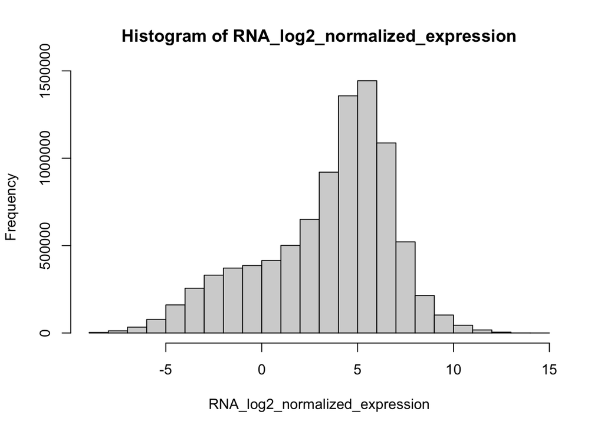

```r
# quick visualization of distribution of the RNA log2 normalized expression values
RNA_log2_normalized_expression <- unlist(rna_normexp)
hist(RNA_log2_normalized_expression)
```

```r
# set cutoffs (see written description in the bullet point below)
(thresh <- 2) # minimum value threshold
```

```
## [1] 2
```

```r
(frac <- 0.99) # minimum fraction of patients
```

```
## [1] 0.99
```

```r
# apply cutoffs
keep <- rowSums(rna_normexp > thresh) > frac*ncol(rna_normexp)
rna_normexp_filt <- rna_normexp[keep,]
```

- Description of filtering cutoff applied to remove lowly expressed genes:
  - require log2(normalized expression value) > 2 (i.e. normalized expression value > 4) in more than 99% of patients

```r
# dimensions of filtered data
dim(rna_normexp_filt)
```

```
## [1] 7388  615
```

Filtering to remove genes with low variance (low standard deviation) across patients:

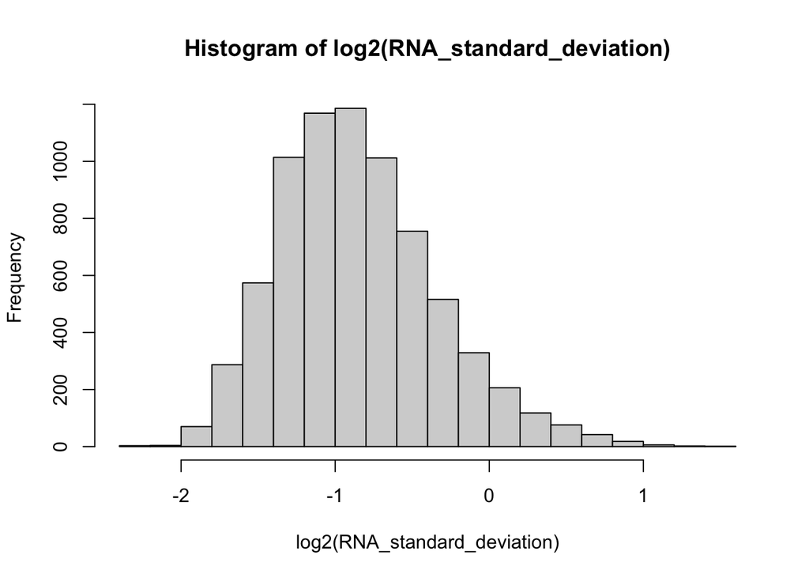

```r
# quick visualization of distribution of the standard deviations
# for the remaining genes after the previous filtering step
row_sds <- apply(rna_normexp_filt, 1, sd)

RNA_standard_deviation <- unlist(row_sds)
hist(log2(RNA_standard_deviation))
```

```r
# set cutoffs (see written description in the bullet point below)
sd_thresh <- 1

# apply cutoffs
keep <- row_sds > sd_thresh
rna_normexp_filt <- rna_normexp_filt[keep,]
```

- Description of filtering cutoff applied to remove low variance genes:
  - require standard deviation of the gene’s RNA expression values > 1

```r
# dimensions of the re-filtered data
dim(rna_normexp_filt)
```

```
## [1] 469 615
```

Generate Z-scaled expression for each filtered gene:

```r
# z-scale each row
rna_zscaled_filt <- t(apply(rna_normexp_filt, 1, base::scale)) %>%
  as.data.frame()

colnames(rna_zscaled_filt) <- colnames(rna_normexp_filt)

# check the format of the scaled data
rna_zscaled_filt[1:5,1:5]
```

|  | P2000 | P2003 | P2004 | P2005 | P2008 |
| --- | --- | --- | --- | --- | --- |
| ACCS | -0.8602368 | 0.0197277 | -0.7575149 | 0.0886346 | -1.2486835 |
| ACSL1 | -0.5712675 | -0.2303809 | -0.2882640 | 0.2405143 | 1.1417800 |
| ADA | -1.3814370 | -0.0152231 | 1.8530192 | 0.2098762 | 0.7219609 |
| ADAM8 | -0.3310099 | 0.4026915 | -1.7185315 | 1.1955110 | 0.1991202 |
| ADNP2 | 1.5846143 | 1.1911335 | 0.1040218 | 0.4379009 | -0.2236509 |

## Genetic mutations

Filter to samples that are in the ID conversion table, then convert sample IDs to patient IDs:

```r
mut <- filter(mut, dbgap_sample_id %in% id_conversion$mut_data_id) %>%
  left_join(select(id_conversion, mut_data_id, patient_id), by = c("dbgap_sample_id" = "mut_data_id"))

# check that the number of patients meets expectations
stopifnot(length(unique(mut$dbgap_sample_id)) == n_patients)
```

Data validity: check the range of “tumor variant allele frequency” (VAF, column `t_vaf`) values, which describes the fraction of mutated reads vs. unmutated reads detected in the cellular mixture. We expect VAF values to be between 5% (typical limit of detection, although higher cutoffs are sometimes applied depending on the study design) and 100% (all reads contain the mutation).

```r
range(mut$t_vaf)
```

```
## [1] 0.08 1.00
```

```r
# assumption checking
stopifnot(min(mut$t_vaf) > 0.05)
stopifnot(max(mut$t_vaf) <= 1)
```

Filter to remove genes that are mutated in very few patients:

```r
# number of mutated patients per gene
# we will only count each patient once, even if they have more than one mutation present in a particular gene
n_mut_pts_per_gene <- distinct(mut, dbgap_sample_id, symbol) %>%
  dplyr::count(symbol)

# set cutoff
min_frac_pts <- 0.05 # minimum fraction of patients in the cohort with mutation
(min_n_muts <- ceiling(min_frac_pts*n_patients)) # minimum number of mutations in cohort required (round up to nearest integer)
```

```
## [1] 31
```

```r
# apply cutoff
genetic_subtypes <- filter(n_mut_pts_per_gene, n >= min_n_muts) %>%
  pull(symbol) %>%
  sort()

# view the list of mutated genes we will be studying
genetic_subtypes
```

```
##  [1] "ASXL1"  "BCOR"   "CEBPA"  "DNMT3A" "FLT3"   "IDH1"   "IDH2"   "KRAS"
##  [9] "NPM1"   "NRAS"   "PTPN11" "RUNX1"  "SF3B1"  "SRSF2"  "STAG2"  "TET2"
## [17] "TP53"   "U2AF1"  "WT1"
```

- Filtering cutoffs applied here: require that the mutation is detected in at least 5% of patients in the cohort (n = 615), i.e. 31 patients have the mutation

Extract the required row and column format from the raw data, and put the patients in the same order as the gene expression data:

```r
mut_matrix <- select(mut, patient_id, gene = symbol) %>%
  filter(gene %in% genetic_subtypes) %>%
  distinct() %>%
  mutate(dummy = 1) %>% # this dummy column will fill in a 1 when a mutation is present in a given patient
  pivot_wider(id_cols = patient_id, names_from = gene, values_from = dummy, values_fill = 0) %>%
  column_to_rownames("patient_id")

# put the genes in alphabetical order
mut_matrix <- mut_matrix[,genetic_subtypes]

# check that the extraction format is correct
mut_matrix[1:5,1:5]
```

|  | ASXL1 | BCOR | CEBPA | DNMT3A | FLT3 |
| --- | --- | --- | --- | --- | --- |
| P2157 | 0 | 0 | 0 | 1 | 0 |
| P2606 | 0 | 0 | 0 | 0 | 1 |
| P2034 | 1 | 0 | 0 | 0 | 0 |
| P2469 | 0 | 0 | 0 | 1 | 0 |
| P2446 | 0 | 0 | 0 | 1 | 1 |

Fill in missing patients. There are patients who did not contain mutations in any of these genes of interest, so we must fill them in as zeros:

```r
unmut_df <- data.frame(patient_id = setdiff(colnames(rna_normexp_filt), rownames(mut_matrix)))

for (i in colnames(mut_matrix)) {
  unmut_df[,i] <- 0
}

unmut_df <- column_to_rownames(unmut_df, "patient_id")

# now add the unmutated patients to the mutated patients matrix
mut_matrix_all <- bind_rows(mut_matrix, unmut_df)

# put the patients in the same order as the RNA gene expression data
# first check that all patients are present
if(setequal(rownames(mut_matrix_all), colnames(rna_normexp_filt))) {
  mut_matrix_all <- mut_matrix_all[patient_order,]
} else {
  stop("Patient set is not in the same as the RNA data! Fix before reordering patients.")
}

# check that the order of patients is identical
stopifnot(identical(rownames(mut_matrix_all), colnames(rna_normexp_filt), attrib.as.set = F))
```

# Statistical testing

To address the question outlined in the *Purpose* section, the Shiny App will need to perform the following statistical test: For each gene in the gene expression dataset (n = 469 genes), compare the Z-scaled expression in mutated patients vs. unmutated patients for each genetic subtype in the mutation dataset (n = 19 genetic subytpes).

- Output layout: rows are the genes in the gene expression dataset, columns are the genetic subtypes, values are the p-values for expression in mutated vs. unmutated patients for the genetic subtyping
- Statistical test: Mann-Whitney-U test (non-parametric test for unpaired data)
- Multiple hypothesis testing correction: Apply FDR correction of p-values after testing for differences in gene-of-interest expression in all 19 genetic subtypes
  - FDR correction is performed by row, because a researcher would be querying one gene from the gene expression dataset and seeing in which genetic subtypes the expression differs based on mutation status
- (Performing all the tests here will make it so the Shiny App doesn’t have to spend time calculating these values on the fly)

```r
# iterate over the genes (rows) in the rna_zscaled_filt gene expression object
for (j in 1:nrow(rna_zscaled_filt)) {
  this_gene <- rownames(rna_zscaled_filt[j,])
  this_stat <- test_gene_expr_in_subtypes(this_gene)

  if (j == 1) {
    stat_results <- this_stat
  } else {
    stat_results <- bind_rows(stat_results, this_stat)
  }
}
```

```r
# check that all genes in the gene expression dataset have been tested
stopifnot(setequal(rownames(rna_zscaled_filt), rownames(stat_results)))
```

# Save results

Save the results of this data preparation, to be used in the Shiny App:

```r
write_rds(rna_normexp_filt, here("AMLsubtypes-geneExpression", "data", "rna_normexp_filt.RDS"))
write_rds(rna_zscaled_filt, here("AMLsubtypes-geneExpression", "data", "rna_zscaled_filt.RDS"))
write_rds(mut_matrix_all, here("AMLsubtypes-geneExpression", "data", "mut_matrix_all.RDS"))
write_rds(stat_results, here("AMLsubtypes-geneExpression", "data", "stat_results_mann_whitney_padj.RDS"))
```

```r
# save an "autocomplete list" of all the gene names that can be queried
write_rds(rownames(rna_normexp_filt), here("AMLsubtypes-geneExpression", "data", "autocomplete_list.RDS"))
```